# TCGA-OV preprocessed from Tatlow and Piccolo, 2016

```r
library(tidyverse)
library(readr)
```

```r
#using preprocessed TCGA-OV TPM from Tatlow and Piccolo, 2016 as was used in Steen et al., 2021 Atlas of clinically distinct cell states and ecosystems across human solid tumors
#TCGA_OV_tpm.tsv.gz from https://osf.io/64ts9/

#In coordination with the Institute for Systems Biology (ISB)34, Tatlow and Piccolo used Google Cloud Platform to process 12,307 RNA-Sequencing samples from the CCLE and TCGA projects. After preprocessing, they aligned sequencing reads to the most current GENCODE reference transcriptome (see Methods) and calculated transcript-expression levels using kallisto, a pseudoalignment and read-quantification program.
#The TCGA samples were available in FASTQ format; therefore, they did not need to sort or convert the data. For sample preprocessing, the FASTQ files were unpacked, decompressed, and quality trimmed
#kallisto is a program for quantifying abundances of transcripts from bulk and single-cell RNA-Seq data, or more generally of target sequences using high-throughput sequencing reads. It is based on the novel idea of pseudoalignment for rapidly determining the compatibility of reads with targets, without the need for alignment.
#The FASTQ files were used as input to kallisto (version 0.43.0)35, which pseudoaligned the reads to the GENCODE reference transcriptome (version 24)59 and quantified transcript-expression levels.
#deposited the processed data—as read counts and transcripts per million—in tabular format and in Google’s BigQuery database (see https://osf.io/gqrz9), output of kallisto

#The IDs used in the TCGA matrices are CGHubAnalysisIDs, which you can't search on the Genomic Data Commons. If you want to change these IDs to something else, you can use map_TCGA_id.py and TCGA_ID_MAP.csv to change them to Aliquot Barcodes or Aliquot ID's, just know that neither of these two identifiers are unique.

#note The 'havana_gene' and 'havana_transcript' attributes indicate the internal gene and transcript stable ids used by Havana and are also the main identifiers in the (now archived) Vega genome browser.They start with 'OTTHUM' and 'OTTMUS' for human and mouse respectively.
TCGA_OV_tpm <- read_delim("/home/lythgo02/ecotyper/downloading_ecotyper_data/Tatlow and Piccolo 2016/TCGA_OV_tpm.tsv",
    delim = "\t", escape_double = FALSE,
    trim_ws = TRUE) %>%
 rename(id=...1) %>% #rename the first column
  separate( col = id, #separating out the identifiers in the first column by non alphanumeric characters
            into=c( "ensembl_transcript_id_version",    #matching to the names in ensembl filters
                    "ensembl_gene_id_version",
                    "havana_gene_id_version",
                    "havana_transcript_id_version",
                    "hgnc_trans_name",
                    "hgnc_symbol",
                    "unknown_number",
                    "transcript_type"),
           sep='\\|', #| is a special character so requires \\
            remove=FALSE)
```

```
## ──────────────────────────────────────────────────────── Delimiter: "\t" chr
## (1): ...1 dbl (430): fae491ab-42b1-413e-b0ff-aa881eb3517e,
## 7afe8a3d-b42a-4c9a-837e-ab0...
```

```r
#or TCGA_OV_tpm <-TCGA_OV_tpm %>% data.frame(do.call("rbind", strsplit(as.character(TCGA_OV_tpm$id), "|", fixed=TRUE))) # separates out and adds as new columns at the end using base R
```

```r
categories <-  # take a look at what makes up the data: 79930 protein coding transcripts
TCGA_OV_tpm %>%
  group_by(transcript_type) %>%
  summarise(transcript_type_count = n())

variants <-TCGA_OV_tpm %>%
  group_by(`hgnc_symbol`) %>%
  summarise(counts=n())

 TCGA_OV_tpm_coding <- TCGA_OV_tpm %>%  #removing retained introns, pseudogene reads, nonsense mediated decay and other non-coding transcripts
   filter(transcript_type=='protein_coding') #shrinks from 199169 to 79930 rows with transcript variants from 19594 genes

# (Intron retention (IR) is an alternative splicing mode whereby introns, rather than being spliced out as usual, are retained in mature mRNAs. Nonsense mediated decay reduces errors in gene expression by eliminating mRNA transcripts that contain premature stop codons.).

 variants_2 <- TCGA_OV_tpm_coding %>%  # taking a look at which genes have multiple transcript versions
   group_by(hgnc_symbol) %>%
   summarise(counts=n())
```

SplicingFactory is an R package for the analysis of alternative splicing isoform diversity. The package provides the ability to generate gene-level Shannon-entropy values and other diversity measures, such as the Gini- or Simpson-index. These measures can quantify transcript isoform diversity within samples or between conditions. Additionally, the package analyzes the isoform diversity data, looking for significant changes between conditions. A basic task during analysis is to use read counts or TPM to calculate a diversity measure and then perform a differential analysis to identify genes with a significant change between conditions. https://bioconductor.org/packages/devel/bioc/vignettes/SplicingFactory/inst/doc/SplicingFactory.html#data-filtering-and-preprocessing

```r
# Extract gene names
genes <- TCGA_OV_tpm_coding[, "hgnc_symbol"]

# Extract read count data without gene names
tpm <- TCGA_OV_tpm_coding[, 10:431]

# Check TPM dataset
dim(tpm)
```

```
## [1] 79930   422
```

[output not shown]

```r
#As a first step, before doing the diversity calculation, you might want to filter out genes with a low overall expression or limit the analysis to transcripts with a sufficient minimum expression level. Expression estimates of transcript isoforms with zero or low expression might be highly variable.

#Here, we are filtering out transcript isoforms with less than 5 reads in more than 5 samples. Additionally, we update the genes vector to match the new filtered matrix.

#tokeep <- rowSums(tpm > 5) > 5
#tpm <- tpm[tokeep, ]
#genes <- genes[tokeep]

#as this matrix is TPM I am not filtering out lowly expressed isoforms yet (may reconsider)

#While SplicingFactory can process any kind of numeric value, used to measure expression levels, we recommend TPM or similar length normalized values.

#calculate_diversity function to calculate two different types of transcript diversity:
#x - Input data, in various formats, discussed in more detail in the Input data structure and Data arrangement section.
#genes - A vector with gene names used for aggregating the transcript level data.
#method - Method to use for splicing diversity calculation.
#norm - If set to TRUE, the entropy values are normalized to the number of transcripts for each gene.
#tpm - In the case of a tximport list, you might want set the tpm argument. As the default option is FALSE, the raw read counts will be extracted from your input data. Set it to TRUE if you want to use TPM values.
#assayno - An optional argument is assayno, which is useful if you are planning to analyze a SummarizedExperiment input, containing multiple assays. assayno is a numeric value, specifying the assay to be analyzed.
#verbose - Set it to TRUE if you want more detailed diagnostic messages.
#To calculate Laplace entropy, where values are normalized between 0 and 1, use:
library(SplicingFactory)
library(SummarizedExperiment)
#the gini index and the laplace entropy reflect transcript diversity

laplace_entropy <- calculate_diversity(tpm, genes$hgnc_symbol, method = "laplace", #not sure if I can perform this on TPM
                                       norm = FALSE, verbose = TRUE)
```

```
## Note: There are 4548 genes with single isoforms,
##     which will be exluded from the analysis.
```

```r
head(assay(laplace_entropy)[, 1:5]) # examine the output using the assay function from SummarisedExperiment
```

```
##        fae491ab-42b1-413e-b0ff-aa881eb3517e
## A1BG                              0.9999949
## A1CF                              2.9999998
## A2M                               0.1769210
## A2ML1                             2.0062869
## A4GALT                            1.4274790
## AAAS                              1.0795268
##        7afe8a3d-b42a-4c9a-837e-ab0b8711ee44
## A1BG                                     NA
## A1CF                              2.9999997
## A2M                               0.2538418
## A2ML1                             2.3219232
## A4GALT                            1.1423633
## AAAS                              0.8573221
##        bd41de75-cd48-4cbd-ace0-ebe960601fea
## A1BG                                     NA
## A1CF                              2.9999935
## A2M                               0.1684469
## A2ML1                             2.3215145
## A4GALT                            1.1440906
## AAAS                              0.7894089
##        1338f5b3-a219-4303-880d-c52c57a2f25a
## A1BG                                     NA
## A1CF                              2.9999929
## A2M                               0.1967405
## A2ML1                             2.3185262
## A4GALT                            1.4325434
## AAAS                              0.8281196
##        c736476f-9e1c-42dc-9be1-923d5d9f210e
## A1BG                                     NA
## A1CF                             2.99999959
## A2M                              0.08817977
## A2ML1                            2.31990704
## A4GALT                           1.32874927
## AAAS                             0.96645998
```

```r
#To calculate Gini index, you don’t need to specify the norm argument, as the Gini index is by definition ranges between 0 (complete equality) and 1 (complete inequality).

gini_index <- calculate_diversity(tpm, genes$hgnc_symbol,  method = "gini",
                                  verbose = TRUE)
```

```
## Note: There are 4548 genes with single isoforms,
##     which will be exluded from the analysis.
```

[output not shown]

```r
head(assay(gini_index)[, 1:5])
```

```
##        fae491ab-42b1-413e-b0ff-aa881eb3517e
## A1BG                              0.1103009
## A1CF                              1.0000000
## A2M                               1.0000000
## A2ML1                             0.8253135
## A4GALT                            0.8005040
## AAAS                              0.9933269
##        7afe8a3d-b42a-4c9a-837e-ab0b8711ee44
## A1BG                                     NA
## A1CF                              1.0000000
## A2M                               1.0000000
## A2ML1                             1.0000000
## A4GALT                            0.7617911
## AAAS                              0.9814028
##        bd41de75-cd48-4cbd-ace0-ebe960601fea
## A1BG                                     NA
## A1CF                              1.0000000
## A2M                               0.9963099
## A2ML1                             0.6487744
## A4GALT                            0.8779183
## AAAS                              0.9574728
##        1338f5b3-a219-4303-880d-c52c57a2f25a
## A1BG                                     NA
## A1CF                              1.0000000
## A2M                               1.0000000
## A2ML1                             0.7896782
## A4GALT                            0.6806742
## AAAS                              0.9927357
##        c736476f-9e1c-42dc-9be1-923d5d9f210e
## A1BG                                     NA
## A1CF                              1.0000000
## A2M                               0.9986571
## A2ML1                             0.7723423
## A4GALT                            0.7200539
## AAAS                              0.9948773
```

Both for the Laplace-entropy and Gini index calculation, the package returns a SummarizedExperiment object, that you can investigate further with the assay function.

The package automatically filters out genes with a single isoform, as splicing diversity values can only be calculated for genes with at least 2 splicing isoforms.

Some genes might show NA diversity values. This means that the expression was zero for all transcript isoforms of the gene in these samples and the package could not calculate any diversity value. Lack of expression might also be the result of technical issues.

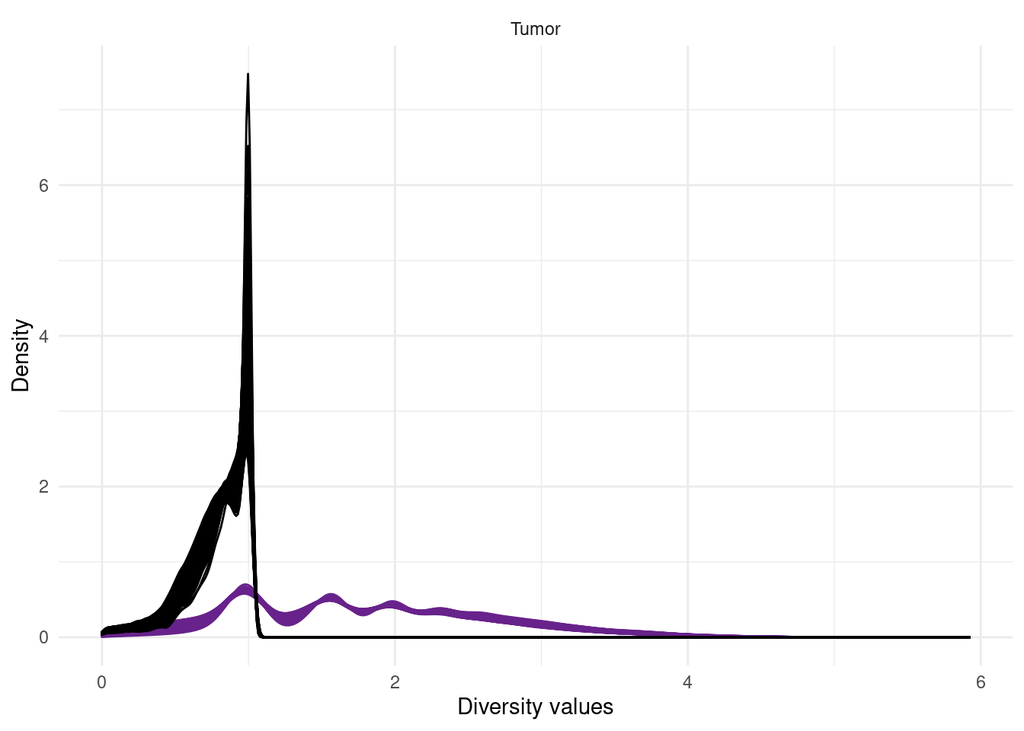

```r
library("ggplot2")

# Construct data.frame from SummarizedExperiment result
laplace_data <- cbind(assay(laplace_entropy),
                      Gene = rowData(laplace_entropy)$genes)

# Reshape data.frame
laplace_data <- pivot_longer(laplace_data, -Gene, names_to = "sample",
                             values_to = "entropy")

# Add sample type information
laplace_data$sample_type <- apply(laplace_data[, 2], 1,
                                  function(x) ifelse(grepl("_N", x),
                                                     "Normal", "Tumor")) # think I need to change the sample ID to this format TCGA-A7-A0CH-11A-32R-A089-07 to get it to work

# Filter genes with NA entropy values
laplace_data <- drop_na(laplace_data)

# Update gene names and add diversity type column
laplace_data$Gene <- paste0(laplace_data$Gene, "_", laplace_data$sample_type)
laplace_data$diversity <-  "Normalized Laplace entropy"

# Construct data.frame from SummarizedExperiment result
gini_data <- cbind(assay(gini_index), Gene = rowData(gini_index)$genes)

# Reshape data.frame
gini_data <- pivot_longer(gini_data, -Gene, names_to = "sample",
                          values_to = "gini")

# Add sample type information
gini_data$sample_type <- apply(gini_data[, 2], 1,
                               function(x) ifelse(grepl("_N", x),
                                                  "Normal", "Tumor"))

# Filter genes with NA gini values
gini_data <- drop_na(gini_data)

# Update gene names and add diversity type column
gini_data$Gene <- paste0(gini_data$Gene, "_", gini_data$sample_type)
gini_data$diversity <-  "Gini index"

# Plot diversity data
ggplot() +
  geom_density(data = laplace_data, alpha = 0.3,
               aes(x = entropy, group = sample, color = diversity)) +
  geom_density(data = gini_data, alpha = 0.3,
               aes(x = gini, group = sample, color = diversity)) +
  facet_grid(. ~ sample_type) +
  scale_color_manual(values = c("black", "darkorchid4")) +
  guides(color = FALSE) +
  theme_minimal() +
  labs(x = "Diversity values",
       y = "Density")
```

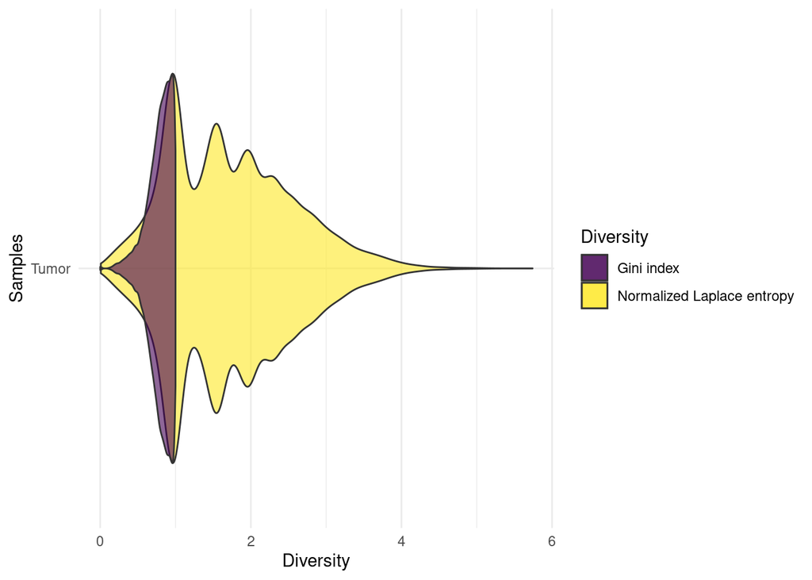

```r
# Mean entropy calculation across samples for each gene/sample type combination
laplace_entropy_mean <- aggregate(laplace_data$entropy,
                                  by = list(laplace_data$Gene), mean)
colnames(laplace_entropy_mean)[2] <- "mean_entropy"
laplace_entropy_mean <- as_tibble(laplace_entropy_mean)

# Add sample type information
laplace_entropy_mean$sample_type <- apply(laplace_entropy_mean[, 1], 1,
                                          function(x) ifelse(grepl("_Normal", x),
                                                             "Normal", "Tumor"))

# Add diversity type column
laplace_entropy_mean$diversity <-  "Normalized Laplace entropy"

# Mean gini calculation across samples for each gene/sample type combination
gini_mean <- aggregate(gini_data$gini, by = list(gini_data$Gene), mean)
colnames(gini_mean)[2] <- "mean_gini"
gini_mean <- as_tibble(gini_mean)

# Add sample type information
gini_mean$sample_type <- apply(gini_mean[, 1], 1,
                               function(x) ifelse(grepl("_Normal", x),
                                                  "Normal", "Tumor"))

# Add diversity type column
gini_mean$diversity <-  "Gini index"

ggplot() +
  geom_violin(data = laplace_entropy_mean, aes(x = sample_type, y = mean_entropy,
                                               fill = diversity),
              alpha = 0.6) +
  geom_violin(data = gini_mean, aes(x = sample_type, y = mean_gini,
                                    fill = diversity),
              alpha = 0.6) +
  scale_fill_viridis_d(name = "Diversity") +
  coord_flip() +
  theme_minimal() +
  labs(x = "Samples",
       y = "Diversity")
```

```r
#selecting a subset of the data as ecotyper will only accept files up to 200kb in size
#TCGA_OV_tpm_hgnc <- TCGA_OV_tpm %>%
#  select(-"id",-"1",-"2",-"3",-"4",-"6",-"7",-"8") %>%
 # select(1:110) %>%
 # write_delim(file="/home/lythgo02/ecotyper/downloading_ecotyper_data/Tatlow and Piccolo 2016/tatlow_picollo_2016_for_ecotyper_1.tsv", delim="\t")
```